# TokyoR 69 LT ggbodeパッケージを作る

niszet

2018/04/21

# 自己紹介

## こんな人です

名前：niszet*  
Rおじさん歴：2年目  
趣味：R、楽器(お休み中)、ラズパイなど

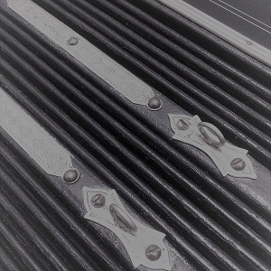

普段は回路設計などしています

# ggplot2で bode線図を描きたい

## bode線図とは

- 周波数によって変化するゲインと位相を見るための図
- 制御や電気電子回路の分野等で系の安定性を見るために使う。
  - ゲイン余裕とか位相余裕とか…

## 先行事例(あまりない)

- そもそも需要がないのでは…(?)
  - niszetも以前やってたらしい（完全に忘れてた）
  - ただし前処理が大量に必要で図の見栄えもイマイチ…

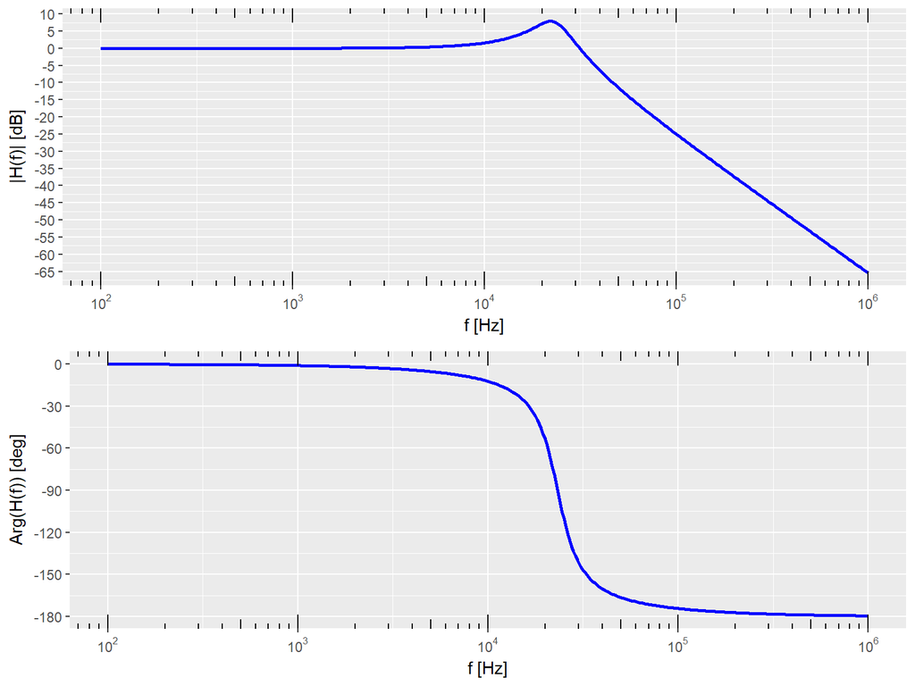

## ご参考

- 抜粋

```r
amplitude = 20*log10(Mod(Hf(f,R,L,C))) #amplitude in dB = 2olog(|H(f)|)
df <- data.frame(x = f, y = amplitude)
p1 <- ggplot(df,aes(x,y)) + geom_line(lwd = 1, col = 'blue') +
  scale_y_continuous(breaks=seq(-65,25,by = 5)) +
  labs(x = "f [Hz]", y = "|H(f)| [dB]") +
  scale_x_log10(breaks = trans_breaks("log10", function(x) 10^x),labels =     trans_format("log10", math_format(10^.x)))+
  annotation_logticks(sides = "bt")

phase = Arg(Hf(f,R,L,C))/pi*180 #phase in deg = arg(H(f))
df <- data.frame(x = f, y = phase)
p2 <- ggplot(df,aes(x,y)) + geom_line(lwd = 1, col = 'blue') +
    scale_y_continuous(breaks=seq(-180,180,by = 30)) +
    labs(x = "f [Hz]", y = "Arg(H(f)) [deg]") +
    scale_x_log10(breaks = trans_breaks("log10", function(x) 10^x),labels =     trans_format("log10", math_format(10^.x)))+
    annotation_logticks(sides = "bt")

grid.arrange(p1,p2)
```

# Rの型

## Rのデータ型(mode)いろいろ

- `integer`
- `numeric`
- `logical`
- `character`
- `raw` (以前紹介。バイナリ)
- `complex` (今回出てきます)

## complex型

- 複素数型。複素数は電気回路とかでよく使うらしい
- 数字のあとにiをつけると複素数型になる（jではダメ）

```r
2i
```

```
## [1] 0+2i
```

```r
complex(real = 1, imaginary = 1)
```

```
## [1] 1+1i
```

- `character`の次に強い型

## complex型の弱点

- ネットにも書籍にも情報がほとんどない…
- `ggplot2`パッケージは直接`complex`型を扱えない
  - Re()`と`Im()`で実部と虚部を取り出して対応
  - `plot()`は`complex`を直接扱える
- メモリをより多く使う

```r
pryr::object_size(numeric(100))
```

```
## 840 B
```

```r
pryr::object_size(complex(100))
```

```
## 1.64 kB
```

# ggbodeへの要求仕様

## とにかく楽にプロットしたい

- MUST: 基本は前処理も関数内に含める
- WANT: カスタマイズできるようにしたい

# 成果

## プロット用のデータ作成

- 自作の1次のLPFの周波数特性を返す関数を使用。

```r
head(lpf(c(3,6e9),1e6, 1e-12))
```

```
##          x            y
## 1 3.000000 1-0.0000188i
## 2 3.366055 1-0.0000211i
## 3 3.776776 1-0.0000237i
## 4 4.237613 1-0.0000266i
## 5 4.754680 1-0.0000299i
## 6 5.334838 1-0.0000335i
```

## えいっ

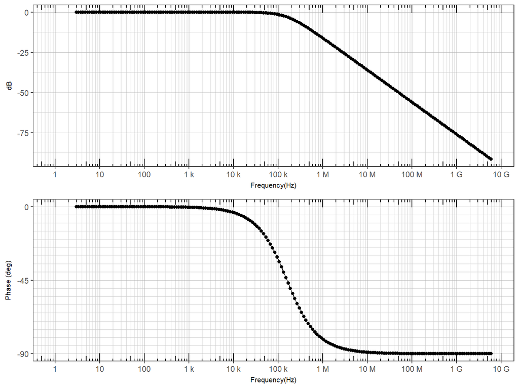

```r
ggbode(lpf(c(3,6e9),1e6, 1e-12), aes(x=x,y=y))
```

# 細かい話

## グラフは2つ同時に表示したい

- 以前は別々の`data.frame`を準備してた（手間）
- `complex`型を受け取ることで1つの列で2つのy軸を作成
- `gridExtra`パッケージでゲインと位相を同時に表示

```r
gridExtra::gtable_rbind(
    ggplot2::ggplotGrob(g1),
        ggplot2::ggplotGrob(g2))
```

## 縦軸はdB（デシベル）や度数表記に

- `ggbode`内部で変換する。

```r
# 値を一旦取り出す
v <- data[[as.character(mapping$y)]]

# デシベル変換(電圧として)
mag_db20 <- 20*log10(v)

# 位相の度数表示への変換
phase <- atan2(Im(v), Re(v)) / pi * 180
```

## x軸の対数表示と目盛

- `scale_x_log10()`を使う
  - `breaks` と `minor_breaks` で主目盛と副目盛をそれぞれ作成
- `xlim`を引数にとれるようにする。
  - `c(6,4e3)`のような値が与えられても副目盛線を調整する

```r
idx <-
    (floor(log10(xlim[1])) - 1):
        (ceiling(log10(xlim[2])) + 1)
breaks_x <- 10 ^ idx
minor_breaks_x <-
    rep(1:9, (idx[length(idx)]-idx[1]+1)) *
        (10 ^ rep(idx, each = 9))
```

## 目盛の見栄え調整

- 目盛の表示が `1E9`とか $1^9$ では見づらい
  - `sitools`パッケージを使って `1G` のように表示させる

```r
scale_x_log10(labels = sitools::f2si)
```

- 対数の補助の目盛が欲しい
  - 下記を追加。

```r
annotation_logticks(sides = "bt")
```

- 対数scale以外に使うとメモリが爆発するので注意
- この正体は `geom_logticks` 、つまり `layer` です。

## 上下限を設定しなくても 良い感じにplotしたい

- `ggplot2` パッケージの `print.ggplot()` 内の `ggplot_build()` でプロットする範囲を求めている

```r
xlim <- ggplot2::ggplot_build(g)[["layout"]]
             [["panel_ranges"]][[1]][["x.range"]]
```

- `ggbode` もこの結果を使っている。
  - 本当は `print.ggbode()` を実装したい。課題。

# まとめ

## まとめ

- 出来たこと
  - bode線図をggplot2パッケージを使って描いた
  - complex型を使った（☜ 重要）
  - minor_breaksなどの処理を取り込んだ
  - パッケージ化の道は遠い…
- 今後の課題
  - パッケージに必要な情報の整備
    - DESCRIPTIONとか色々
  - `facet`の対応が難しい…
  - 色々な設定に対応する

## Enjoy!!

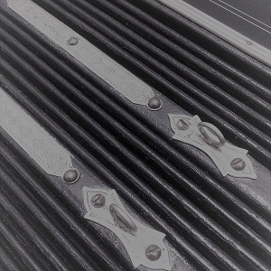